# Assignment 17: Data Simulation

*How to do it?*:

- Open the Rmarkdown file of this assignment (link) in Rstudio.
- Right under each **question**, insert a code chunk (you can use the hotkey `Ctrl + Alt + I` to add a code chunk) and code the solution for the question.
- `Knit` the rmarkdown file (hotkey: `Ctrl + Alt + K`) to export an html.
- Publish the html file to your Githiub Page.

*Submission*: Submit the link on Github of the assignment to Canvas

**Notice:** *In this assignment, all the plot should have title, caption, and axis labels.*

### 1. Simulating Data for a model

Suppose we want to simulate data from the following linear model

$$y = 2 + 3 x + \epsilon$$
where $\epsilon \sim N(0, 1)$.

To simulate data, we first need specify values for $x$. We use `rnorm` to generate data from the normal distribution and `runif` to generate data from the uniform distribution.

```r
n = 1000
x = runif(n = n, 0, 10)
e = rnorm(n=100, mean = 0, sd = 1)
y = 2+3*x + e
```

Use the linear model to estimate the coefficient with the simulated the data.

```r
lm(y~x)
```

```
##
## Call:
## lm(formula = y ~ x)
##
## Coefficients:
## (Intercept)            x
##       2.025        2.982
```

We see that the linear model does a very good job estimating the true value of the coefficients.

Do the follows.

- Simulate data for the following model and use linear model to recover the coefficients. How well the linear model fits the data? Hint: Use `lm(y ~ x1 + x2)` for multiple linear regression.

$$y = 2 + 3 x_1 + 4x_2 + \epsilon$$
where $\epsilon \sim N(0, 2)$.

```r
n = 1000
x1 = runif(n=n,0,10)
x2 = runif(n=n,0,10)
e = rnorm(n=100, mean = 0, sd = 2)

y = 2 + 3*x1 + 4*x2 + e
```

```r
lm(y ~ x1 + x2)
```

```
##
## Call:
## lm(formula = y ~ x1 + x2)
##
## Coefficients:
## (Intercept)           x1           x2
##       2.352        2.997        3.979
```

### 2. Simulating Data to test the Central Limit Theorem

The central limit theorem says that the sample means of any distribution follows the normal distribution with the same population mean. Do the follows to verify the theorem

- Generate m = 10,000 samples from uniform distribution, each sample has the size $n = 1000$. Hint: Generate $m \times n$ random numbers and organize them in a matrix where each columns is a sample.

```r
m = 10000
n = 1000

Q2points <- runif(m*n)

Q2 <- matrix(data = Q2points, nrow = n, ncol = m)
```

- Calculate the means of each samples (The column means of the matrix)

```r
Q2Means <-colMeans(Q2)
```

- Plot the histogram of the means and verify that the histogram shows the normal distribution of the means.

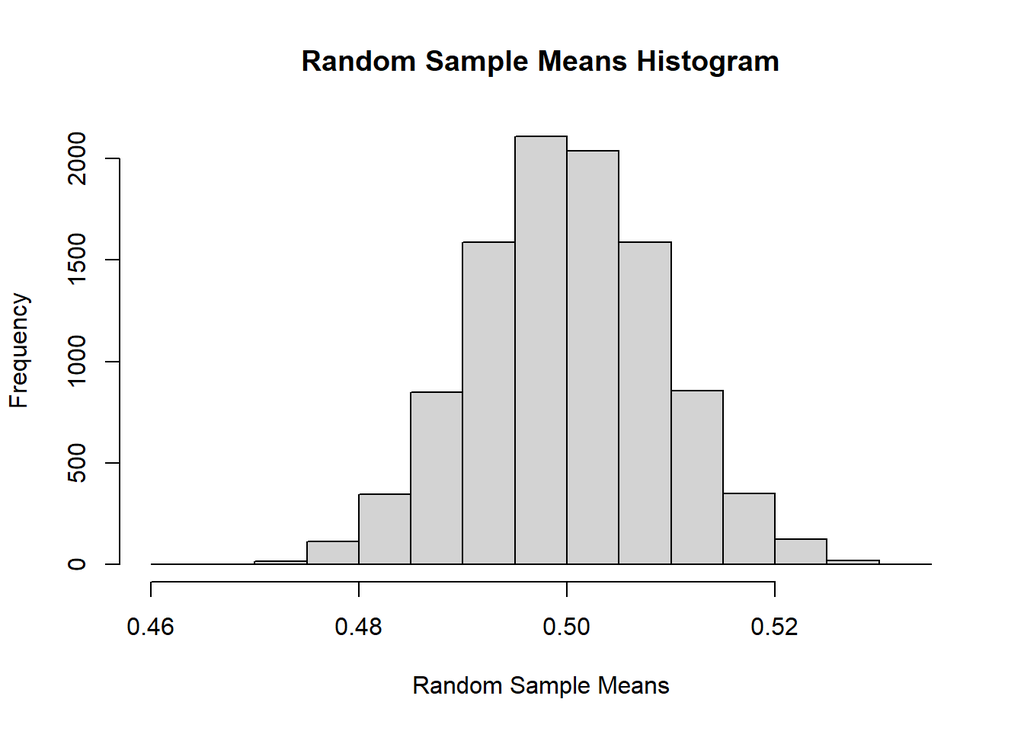

```r
library(ggplot2)
library(tidyverse)

hist(Q2Means,
     main = "Random Sample Means Histogram",
     xlab = "Random Sample Means",
     ylab = "Frequency")
```

Redo the above steps for the distribution of the number of values getting when rolling a die. [Hint: Use `sample(c(1: 6), n, replace = TRUE)` to generate samples from rolling a die]

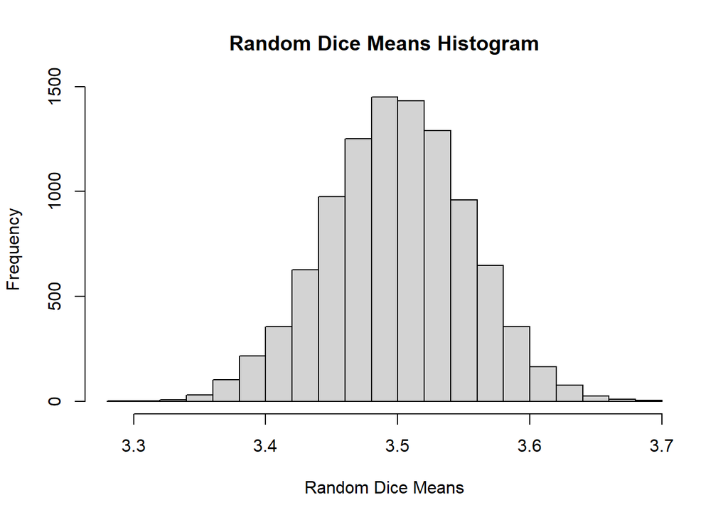

```r
Q2DicePoints <- sample(c(1:6),n*m, replace=T)

Q2Dice <- matrix(data = Q2DicePoints, nrow = n, ncol = m)

Q2DiceMeans <- colMeans(Q2Dice)

hist(Q2DiceMeans,
     main = "Random Dice Means Histogram",
     xlab = "Random Dice Means",
     ylab = "Frequency")
```

### 3. (Monte Carlo Methods) Estimating Pi

[figure not shown]

Do the following to estimate $\pi$

- Generating n = 1000 values of $x$ from the uniform distribution from -1 to 1 using `runif`

```r
n = 1000
x <- runif(n,-1,1)
```

- Generating n = 1000 values of $y$ from the uniform distribution from -1 to 1 using `runif`

```r
y <- runif(n, -1,1)
```

- Counting the number of points $(x,y)$ within the circle by counting the number of points such that $x^2 + y^2 \leq 1$.

```r
df <- data.frame(col1 = x,
                 col2 = y)

df$xsquare <- (df$col1)^2

df$ysquare <- (df$col2)^2

df$total <- df$xsquare + df$ysquare

count <- 0

for (i in 1:n)(
  if (df$total[[i]] <= 1)
  {
    count <- count + 1
  }
)
```

- We have the area of a circle is calculated by $A_1 = \pi r^2$, and the area of the bounding square is $A_2 = 4r^2$. We have

$$\frac{\pi}{4} = \frac{\pi r^2}{4r^2} = \frac{A_1}{A_2} \approx
\frac{\text{Number of Points within the circle}}{\text{Total Number of
Points}}$$

- Estimating $\pi$ from the above equation.

```r
# (# of points within / n ) * 4 = pi

count / n * 4
```

```
## [1] 3.116
```

- Increase the value of $n$ for more accurate estimation for $\pi$.

```r
n = 100000
x <- runif(n,-1,1)
y <- runif(n, -1,1)
df <- data.frame(col1 = x,
                 col2 = y)

df$xsquare <- (df$col1)^2

df$ysquare <- (df$col2)^2

df$total <- df$xsquare + df$ysquare

count <- 0

for (i in 1:n)(
  if (df$total[[i]] <= 1)
  {
    count <- count + 1
  }
)

count / n * 4
```

```
## [1] 3.142
```